# Module 2 Exercises

## Exercise for Module 2

**TipObjectives**

- Compare common variables in linked administrative health data.
- Become familiar with end of record loading.
- Construct a study population from longitudinally linked data.
- Use the study population to start examining simple research questions.

## Context

Kidney transplantation is the most compelling treatment option for kidney failure, conferring both survival and quality of life benefits. A kidney can be donated from either a living donor or a deceased donor. Once a kidney transplant fails, people may go on to receive another kidney transplant. Some patients also require a liver transplant, either concurrently or at a different time to kidney transplantation. This exercise will give you the opportunity to explore kidney transplantation in administrative health data.

Please note that while these are real data of real individuals, you have been provided with a perturbed selection and so estimates are not reflective of true transplantation rates.

## PART ONE

Patient demographics are collected across several administrative health datasets. We have provided age and sex from redacted data across several health administrative databases. Use these data to make comparisons within and across datasets to decide upon the most appropriate value to use for each patient.

**canc_reg.csv** – Cancer registry, includes age and sex at cancer diagnosis, and date of cancer diagnosis.  
**napd.csv** – Non-admitted patient data, includes age and sex at date of outpatient service, and date of outpatient service.  
**pbs.csv** – Pharmaceutical Benefits Scheme, includes age and sex at date of dispensing medication, and date of dispensing medication.  
**dth.csv** – Deaths records, includes age and sex at date of death, and date of death.  
**anzdata.csv** – Australian and New Zealand Dialysis and Transplant Registry data, includes age and sex at date of receiving dialysis or transplant, and date of dialysis or transplant.

## Question 1

For each of the datasets, prepare datasets as required and create an approximate date of birth from the age given at each of the relevant dates.

## Question 2

For each of the datasets, create a variable for the year of the approximate date of birth.

Some datasets contain multiple rows per patient (ppn), with potentially different values for the year of approximate date of birth.

Compare the year of approximate date of births within each ppn and each dataset. Select only one year of approximate date of birth per ppn based on the most frequently reported value.

Would it be possible to do the same for the month of approximate date of birth?

## Question 3

Merge the datasets together.

## Question 4

Similar to Question 2, compare the year of approximate date of birth within each ppn and now across the datasets. Select only one year of approximate date of birth based on the most frequently reported value.

## Question 5

How many occurrences did the most frequently reported year of approximate date of birth match to ANZDATA year of approximate date of birth?

**NoteNote**

Date of birth is becoming increasingly less common to be provided from administrative health datasets. It generally is not a necessary as age at onset is provided and can be used in analyses. However, consistency between the datasets is important to ensure analyses are robust.

## Question 6

How might your approach change if you had been given an exact date instead?

## Question 7 (Optional)

Using the same approach as above, compare the sex within the datasets first and then across the datasets. How many discrepancies have occurred?

## PART TWO

In this part, you will be using the data from the Australian and New Zealand Dialysis and transplant registry to count first-time and total events and *conduct a point and period census*.

## Question 1

Import **kidney_long.csv** and save into data frame (**kidney_long**). Familiarize yourself with the data items.

The file includes kidney transplant recipients and the date and donor type of their respective kidney transplants. Some people may receive multiple kidney transplants over their lifetime.

Create a *tx_seq* sequence variable that counts each kidney transplant for each patient.

How many people in the dataset received 2 or more kidney transplants?

## Question 2

Now write and run the code to create an *“index_seq”* variable (call this variable *post_ltx_seq*) on the end of each record to flag for living donor transplants. Assign a value of 1 for the first record where the kidney transplant was from a living donor (using the donortype variable) and then count any subsequent kidney transplants. This variable flags the first living donor kidney transplant and counts all subsequent kidney transplants regardless of the type of donor (i.e. living or deceased donor).

1. How many patients had at least one kidney transplant from a living donor?
2. How many patients with a living kidney donor transplant had at least one subsequent kidney transplant?

## Question 3

For patients who had another kidney transplant after their living donor transplant, most will have a deceased donor transplant but some may have another living donor transplant. Write and run the code that creates a variable *liv_seq* (living donor transplant sequence) on the end of each record. This assigns the value of 1 for the index record (first living donor transplant) and increments each time a subsequent transplant is from a living donor.

1. What is maximum number of living donor transplants to one patient in our study population?
2. How many patients had at least one additional living donor transplant after their first living donor transplant?

Your sequence numbering should look like the following output. Note the difference between the *post_ltx_seq* and *liv_seq*. We suggest you check your coding using the patient with ID “P9119912”.

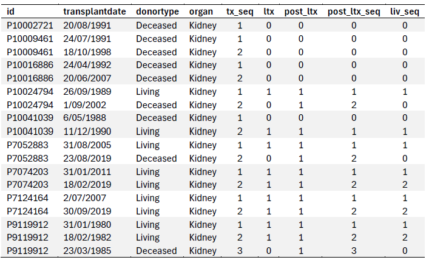

## Question 4

For the below questions, we want to look at the donor type of subsequent kidney transplants following a living donor transplant.

**CautionHint**

Remind yourself of what the *post_ltx_seq* variable represents and restrict the records you will look at using the *post_ltx_seq* variable

We want to determine whether having a living donor kidney transplant, either as the first kidney transplant or subsequent kidney transplant, influences the donor type of their next kidney transplant (if any). That is, does the proportion of patients whose next kidney transplant is from a living donor differ depending on whether their first kidney transplant was a living donor or a deceased donor?

Now, remembering that the *post_ltx_seq* variable counts from the first living donor transplant (which may not be the first kidney transplant for the patient as they may have had prior kidney transplants) and *tx_seq* variable counts all their kidney transplants. Using *post_ltx_seq* and *tx_seq* appropriately:

1. Determine what proportion of patients had a deceased donor transplant immediately following their first living donor transplant.
2. Determine what proportion of patients had a deceased donor transplant immediately following their first living donor transplant, where their first living donor transplant was also their first ever kidney transplant.
3. Determine what proportion of patients had a deceased donor transplant following their first living donor transplant which was NOT their first kidney transplant.

## Question 5

What might be some of the limitations of using these data?